# Practical 7: Time Series

Nina van Gerwen (1860852)

2023-01-12

## 1: Introduction

```r
library(expsmooth)
library(fpp3)
library(fable.prophet)
```

## 2: Take-home exercises

### 2.1: Data exploration

#### 2.1.1: Describing the structure of the data

```r
data(ukcars)
ukcars %>% str()
```

```
##  Time-Series [1:113] from 1977 to 2005: 330 371 271 344 358 ...
```

The ukcars dataset is a time-series dataset from 1977 to 2005 with 113 values. This means the data is probably seasonal/quarterly.

#### 2.1.2: Converting to tsibble

```r
ts_cars <- ukcars %>% as_tsibble(.)
```

ts_cars has a different structure. It is no longer a time-series. Instead, it is a time-series tibble (i.e., a tibble with an index variable that denotes the time of the observations).

### 2.1.3: Some line plot visualisation

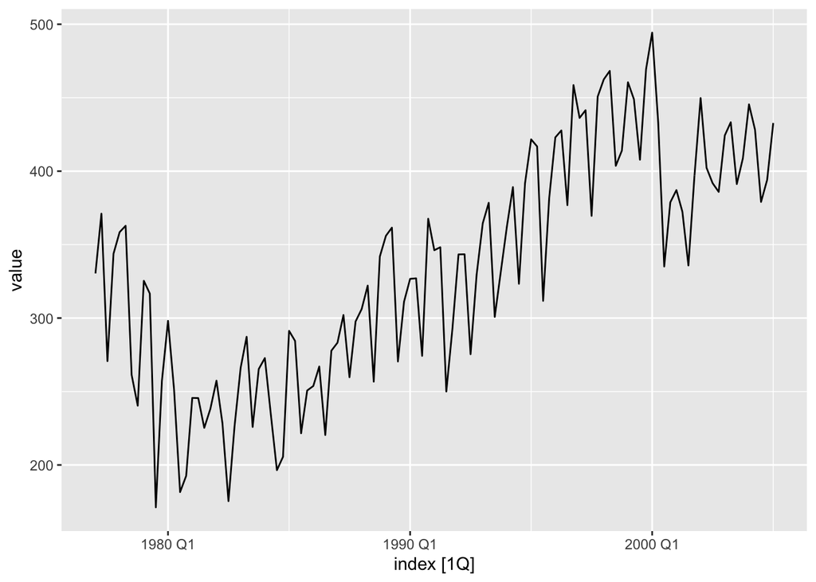

```r
ts_cars %>% autoplot(value)
```

There seems to be a large seasonal effect and a somewhat increasing trend past 1980.

#### 2.1.4: Further line plot visualisations

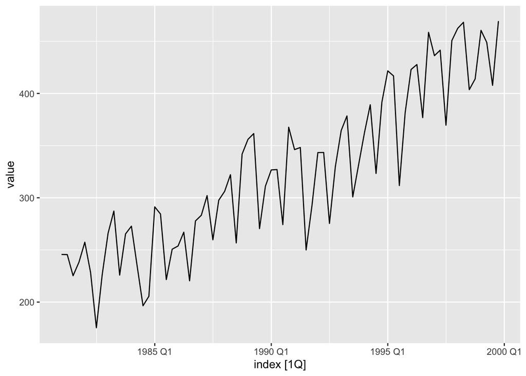

```r
ts_cars %>% filter(year(index) > 1980 & year(index) < 2000) %>%
  autoplot(value)
```

When looking only at the period between 1980 and 2000, the increasing trend becomes even more obvious with the same seasonal effect as before.

### 2.1.5: Plotting the autocorrelation

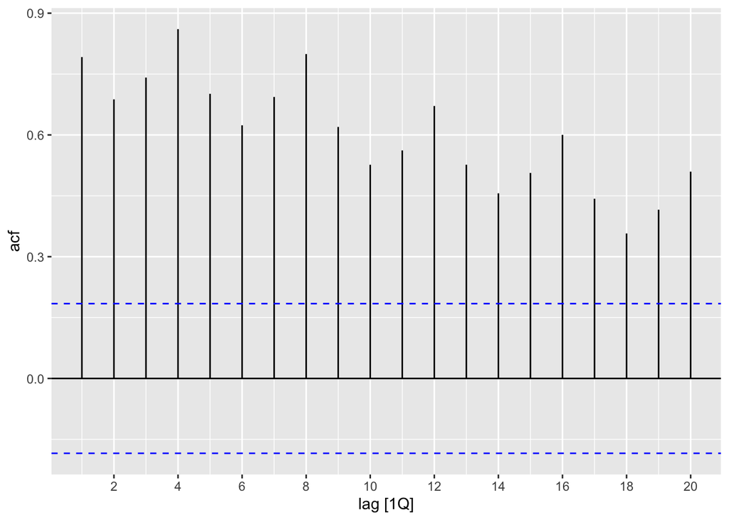

```r
ts_cars %>% ACF(value) %>% autoplot(.)
```

Specific features to notice about this plot is the returning pattern every 4 lags. Furthermore, autocorrelation for every lag is significant.

## 3: Lab exercises

### 3.1: Decomposition

#### 3.1.6: Creating an STL decomposition

```r
set.seed(1248)
STL_decomp <- ts_cars %>%
  model(STL(value ~ trend(window = 15) + season(window = Inf))) %>%
  components()

STL_decomp %>%
  head()
```

```
## # A dable: 6 x 7 [1Q]
## # Key:     .model [1]
## # :        value = trend + season_year + remainder
##   .model                   index value trend season_year remainder season_adjust
##   <chr>                    <qtr> <dbl> <dbl>       <dbl>     <dbl>         <dbl>
## 1 STL(value ~ trend(win… 1977 Q1  330.  342.       25.1      -36.9          305.
## 2 STL(value ~ trend(win… 1977 Q2  371.  336.       21.1       14.4          350.
## 3 STL(value ~ trend(win… 1977 Q3  271.  329.      -44.9      -13.5          316.
## 4 STL(value ~ trend(win… 1977 Q4  344.  322.       -1.29      23.1          345.
## 5 STL(value ~ trend(win… 1978 Q1  358.  315.       25.1       18.3          333.
## 6 STL(value ~ trend(win… 1978 Q2  363.  308.       21.1       33.6          342.
```

#### 3.1.7: Plotting the individual components

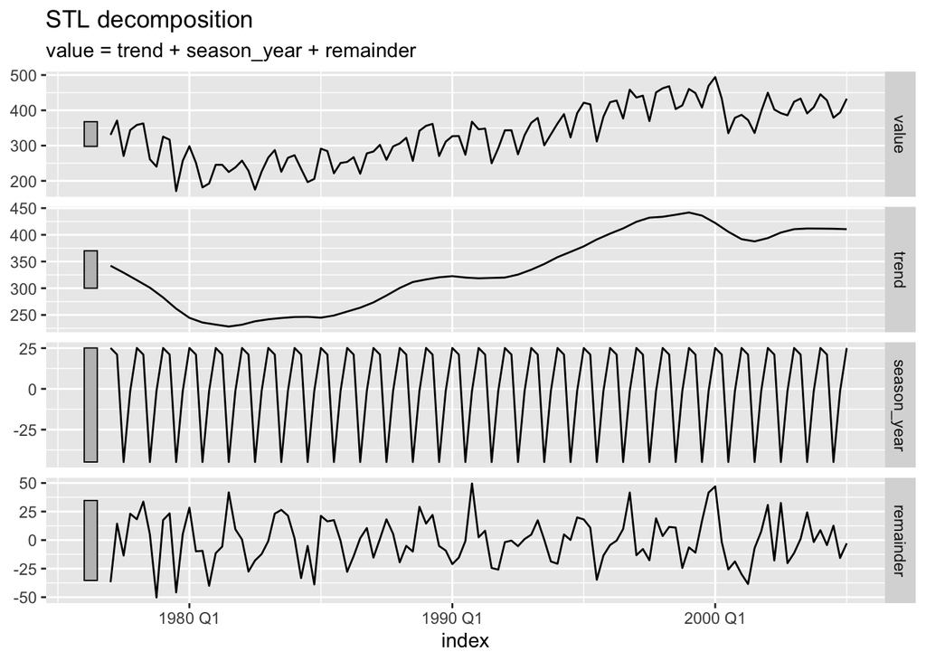

```r
STL_decomp %>% autoplot()
```

#### 3.1.8: Plotting the autocorrelation of the remainder

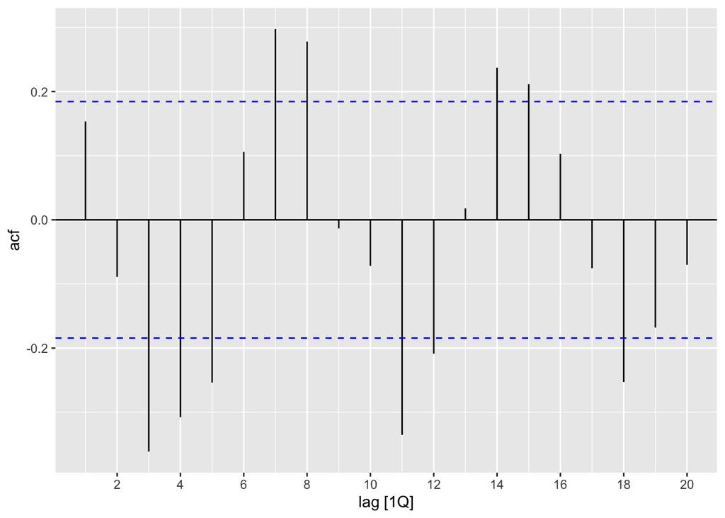

```r
STL_decomp %>%
  select(remainder) %>%
  ACF(remainder) %>%
  autoplot(.)
```

### 3.2: ARIMA modeling

#### 3.2.9: Creating two ARIMA models

```r
models <-
  ts_cars %>%
  model(
    ARIMA = ARIMA(value ~ pdq(1, 1, 1) + PDQ(0, 0, 0)),
    SARIMA = ARIMA(value)
  )
```

The first ARIMA model is an Autoregressive Integrated Moving Average model, with three parts: First, an autoregressive model with lag 1, this means that value $y_t$ is autoregressed on only the first value before it (i.e., $y_{t-1}$). Second, we don’t work with the actual values but the difference between the values (in order to achieve stationarity). And third, the model also includes a Moving Average part. This means that value $y_t$ is also predicted by the the first error before the value (i.e., $y_t$ is dependent on $\epsilon_{t-1}$). Furthermore, there is *NO* seasonality in this model (defined by the PDQ(0, 0, 0) part).

The second model, instead, is an automatic ARIMA specification, where it has simply chosen the best model (i.e., lowest AIC) after testing multiple models. The outcome for this model was a model with pdq(1,0,1) + PDQ(1,1,2).

#### 3.2.10: Creating forecasts

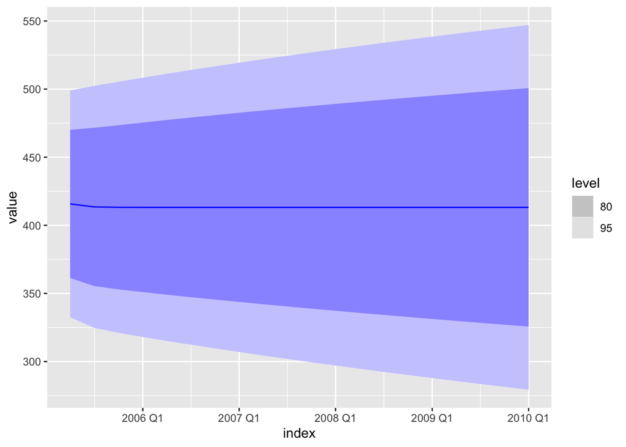

```r
models %>%
  select(ARIMA) %>%
  forecast(., h = "5 years") %>%
  autoplot(.)
```

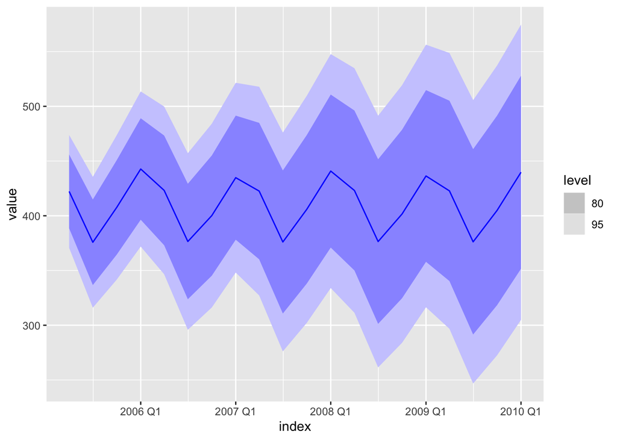

```r
models %>%
  select(SARIMA) %>%
  forecast(., h = "5 years") %>%
  autoplot(.)
```

The main difference is obviously the seasonsality, which the SARIMA model accounts for, whereas the ARIMA model does not. Furthermore, the SARIMA model seems to have smaller intervals (which is to be expected as it was the model with the lowest AIC). However, this might be due to overfitting.

An obvious similarity between both plots is that for both plots, the variance of the point forecasts increases with time, as it should.

### 3.3: Comparing SARIMA and Prophet forecasting methods

#### 3.3.11. Fitting a data-driven ARIMA and a prophet model

```r
ARIMA_FC <- ts_cars %>%
  filter(year(index) > 1980 & year(index) < 1995) %>%
  model(ARIMA(value)) %>%
  forecast(., h = "5 years")

PROPH_FC <- ts_cars %>%
  filter(year(index) > 1980 & year(index) < 1995) %>%
  model(prophet(value)) %>%
  forecast(., h = "5 years")

MSE(.resid = ARIMA_FC$.mean, .actual = filter(ts_cars, year(index) > 1995 & year(index) < 2000))
```

```
## [1] 153884.7
```

```r
MSE(.resid = PROPH_FC$.mean, .actual = filter(ts_cars, year(index) > 1995 & year(index) < 2000))
```

```
## [1] 147688.6
```

According to the mean squared error, the prophet model has better predictions.